# **DS220: Project #2 U.S Fatal Police Shooting**

## Data Analysis with Python Pandas - [Shen-Han Chiu]

## > Professor Mathias Fonkam

## > Submitted on Dec 7th, 2023

# Part 1: Introduction of the Dataset

### In this Jupyter Notebook, I have implemented the data analysis of a fatal-police-shooting dataset, and I used visualization tools to address some of the research questions. First of all, the dataset was collected from the Kaggle Website [link text](https://www.kaggle.com/datasets/andrewmvd/police-deadly-force-usage-us) (i.e, kaggle datasets download -d andrewmvd/police-deadly-force-usage-us), a public dataset source for exploring, analyzing, and sharing quality data. Second, the dataset of police shooting is an overview of every fatal shooting that is involved with a police officer in the United States. But a lot of questions for understanding the dataset and uncovering the hidden patterns, even meaningful insights from the dataset, were framed based on the information found in 2015 to 2020 (recorded by the Federal Bureau of Investigation and the Centers for Disease Control and Prevention). I suspect that there is more documentation of the fatal shootings by police, not FBI. According to the dataset and officials from the FBI, they acknowledge that the dataset was in fact incomplete and therefore only offer this set of data for education purposes.

### The objective of the project is to allow readers to understand the analysis of the fetal shooting data and not just viewing the pie chart and graphs but also associating the data with the public perception of the police system based on the number of officer shootings. The steps towards the analysis of the data were loading the dataset, exploratory data analysis, data cleaning, visualizations, and conclusion. It is essential to develop data visualization and code around these powerful libraries.

### For this project, I introduce and integrate important libraries such as **pandas**, **matplotlib**, **numpy**, warnings and data science tables. I was able to load the dataset and there are **14** columns and **5416** records of police shootings(e.g., id, name, date, manner_of_death, armed, age, gender, race, city, state, signs_of_mental_illness, threat_level, flee, and body_camera).

### 1. ID

### 2. Name

### 3. Date

### 4. Manner_of_death

### 5. Armed

### 6. Age

### 7. Gender

### 8. Race

### 9. City

### 10. State

### 11. Signs_of_mental_illness

### 12. Threat_level

### 13. Flee

### 14. Body_camera

### Task 1: Importing the Libraries

### In this section, I introduce and integrate important libraries in an effort to improve the capabilities of our notebook. We integrate the features of seaborn and matplotlib, which are essential for enabling aesthetically engaging data visualisations, by supplying the pertinent code snippets. Furthermore, the pandas library is included, which gives us powerful tools for smooth data manipulation and in-depth analysis inside our notebook.

### * Import all necessary libraries in the code cell below;

### * Pandas, matplotlib, numpy, and datascience

```python
import pandas as pd
import warnings
warnings.filterwarnings('ignore')
import matplotlib.pyplot as plt
from scipy.stats import chi2_contingency
import seaborn as sns
from sklearn.model_selection import train_test_split
from sklearn.metrics import accuracy_score, mean_squared_error
from sklearn.linear_model import LogisticRegression
import numpy as np
```

```python
#import warnings
#warnings.filterwarnings("ignore")
#from datascience import Table
#from datascience import *
#import numpy as np
#import matplotlib
#matplotlib.use('Agg')
#%matplotlib inline
#import matplotlib.pyplot as plots
#plots.style.use('fivethirtyeight')
```

### Task 2: Loading the Dataset

```python
df = pd.read_csv('fatal-police-shootings-data.csv')
df
```

|  | Id | Name | Date | Manner_of_death | Armed | Age | Gender | Race | City | State | Signs_of_mental_illness | Threat_level | Flee | Body_camera |
| --- | --- | --- | --- | --- | --- | --- | --- | --- | --- | --- | --- | --- | --- | --- |
| 0 | 3 | Tim Elliot | 1/2/2015 | shot | gun | 53.0 | M | A | Shelton | WA | True | attack | Not fleeing | False |
| 1 | 4 | Lewis Lee Lembke | 1/2/2015 | shot | gun | 47.0 | M | W | Aloha | OR | False | attack | Not fleeing | False |
| 2 | 5 | John Paul Quintero | 1/3/2015 | shot and Tasered | unarmed | 23.0 | M | H | Wichita | KS | False | other | Not fleeing | False |
| 3 | 8 | Matthew Hoffman | 1/4/2015 | shot | toy weapon | 32.0 | M | W | San Francisco | CA | True | attack | Not fleeing | False |
| 4 | 9 | Michael Rodriguez | 1/4/2015 | shot | nail gun | 39.0 | M | H | Evans | CO | False | attack | Not fleeing | False |
| ... | ... | ... | ... | ... | ... | ... | ... | ... | ... | ... | ... | ... | ... | ... |
| 5411 | 5921 | William Slyter | 6/13/2020 | shot | gun | 22.0 | M | W | Kansas City | MO | False | other | Other | False |
| 5412 | 5922 | TK TK | 6/13/2020 | shot | undetermined | NaN | M | NaN | San Bernardino | CA | False | attack | Not fleeing | False |
| 5413 | 5924 | Nicholas Hirsh | 6/15/2020 | shot | gun | 31.0 | M | W | Lawrence | KS | False | attack | Car | False |
| 5414 | 5926 | TK TK | 6/16/2020 | shot | gun | 24.0 | M | NaN | Beach Park | IL | False | attack | Not fleeing | False |
| 5415 | 5927 | TK TK | 6/16/2020 | shot | gun | 27.0 | M | NaN | Phoenix | AZ | False | attack | Not fleeing | False |

5416 rows × 14 columns

# Part 2: Exploratory Data Analysis

### It is extremely important to examine the data before conducting any sort of research on it, I attempt to gain a better understanding of the dataset in this section. In order to do that, I attempt to show the top 5 rows of the data and last 5 rows of the data. It is also important to know the shape of the dataset to check the total number of rows and columns present in the data, understand the information of data types, non-null values of all the columns in the dataset.

```python
# return the top 5 rows of the data
df.head()
```

|  | Id | Name | Date | Manner_of_death | Armed | Age | Gender | Race | City | State | Signs_of_mental_illness | Threat_level | Flee | Body_camera |
| --- | --- | --- | --- | --- | --- | --- | --- | --- | --- | --- | --- | --- | --- | --- |
| 0 | 3 | Tim Elliot | 1/2/2015 | shot | gun | 53.0 | M | A | Shelton | WA | True | attack | Not fleeing | False |
| 1 | 4 | Lewis Lee Lembke | 1/2/2015 | shot | gun | 47.0 | M | W | Aloha | OR | False | attack | Not fleeing | False |
| 2 | 5 | John Paul Quintero | 1/3/2015 | shot and Tasered | unarmed | 23.0 | M | H | Wichita | KS | False | other | Not fleeing | False |
| 3 | 8 | Matthew Hoffman | 1/4/2015 | shot | toy weapon | 32.0 | M | W | San Francisco | CA | True | attack | Not fleeing | False |
| 4 | 9 | Michael Rodriguez | 1/4/2015 | shot | nail gun | 39.0 | M | H | Evans | CO | False | attack | Not fleeing | False |

```python
# return the last 5 rows of the data
df.tail()
```

|  | Id | Name | Date | Manner_of_death | Armed | Age | Gender | Race | City | State | Signs_of_mental_illness | Threat_level | Flee | Body_camera |
| --- | --- | --- | --- | --- | --- | --- | --- | --- | --- | --- | --- | --- | --- | --- |
| 5411 | 5921 | William Slyter | 6/13/2020 | shot | gun | 22.0 | M | W | Kansas City | MO | False | other | Other | False |
| 5412 | 5922 | TK TK | 6/13/2020 | shot | undetermined | NaN | M | NaN | San Bernardino | CA | False | attack | Not fleeing | False |
| 5413 | 5924 | Nicholas Hirsh | 6/15/2020 | shot | gun | 31.0 | M | W | Lawrence | KS | False | attack | Car | False |
| 5414 | 5926 | TK TK | 6/16/2020 | shot | gun | 24.0 | M | NaN | Beach Park | IL | False | attack | Not fleeing | False |
| 5415 | 5927 | TK TK | 6/16/2020 | shot | gun | 27.0 | M | NaN | Phoenix | AZ | False | attack | Not fleeing | False |

```python
# return the shape of the dataset to check the total number of rows and columns present in the data
df.shape
```

```
(5416, 14)
```

```python
# return the information of data types, non null values of all the columns in the dataset
df.info()
```

```
<class 'pandas.core.frame.DataFrame'>
RangeIndex: 5416 entries, 0 to 5415
Data columns (total 14 columns):
 #   Column                   Non-Null Count  Dtype
---  ------                   --------------  -----
 0   Id                       5416 non-null   int64
 1   Name                     5416 non-null   object
 2   Date                     5416 non-null   object
 3   Manner_of_death          5416 non-null   object
 4   Armed                    5189 non-null   object
 5   Age                      5181 non-null   float64
 6   Gender                   5414 non-null   object
 7   Race                     4895 non-null   object
 8   City                     5416 non-null   object
 9   State                    5416 non-null   object
 10  Signs_of_mental_illness  5416 non-null   bool
 11  Threat_level             5416 non-null   object
 12  Flee                     5167 non-null   object
 13  Body_camera              5416 non-null   bool
dtypes: bool(2), float64(1), int64(1), object(10)
memory usage: 518.5+ KB
```

As you can see from the results above, several of the columns—including gender, race, armed status, name, date, and others—are of the object type, which means that they include data in the form of string values. It is also obvious that some columns have non-null values that are fewer than the total number of rows because there are 5416 rows in all. And it indicates that some of the values in our dataset are missing.

```python
# return the statistics for the numerical columns present in the dataset.
df.describe()
```

|  | Id | Age |
| --- | --- | --- |
| count | 5416.000000 | 5181.000000 |
| mean | 3010.398264 | 37.117931 |
| std | 1695.786456 | 13.116135 |
| min | 3.000000 | 6.000000 |
| 25% | 1545.750000 | 27.000000 |
| 50% | 3009.500000 | 35.000000 |
| 75% | 4486.250000 | 46.000000 |
| max | 5927.000000 | 91.000000 |

### As we require clean data for future analysis, visualisation, and machine learning modelling, we will clean the data in this part to ensure that it is free of missing values and unnecessary information.

```python
# First converting the false and true to 0 and 1
for col in ['Signs_of_mental_illness','Body_camera']:
    df[col].replace([False,True],[0,1], inplace = True)

df.head()
```

|  | Id | Name | Date | Manner_of_death | Armed | Age | Gender | Race | City | State | Signs_of_mental_illness | Threat_level | Flee | Body_camera |
| --- | --- | --- | --- | --- | --- | --- | --- | --- | --- | --- | --- | --- | --- | --- |
| 0 | 3 | Tim Elliot | 1/2/2015 | shot | gun | 53.0 | M | A | Shelton | WA | 1 | attack | Not fleeing | 0 |
| 1 | 4 | Lewis Lee Lembke | 1/2/2015 | shot | gun | 47.0 | M | W | Aloha | OR | 0 | attack | Not fleeing | 0 |
| 2 | 5 | John Paul Quintero | 1/3/2015 | shot and Tasered | unarmed | 23.0 | M | H | Wichita | KS | 0 | other | Not fleeing | 0 |
| 3 | 8 | Matthew Hoffman | 1/4/2015 | shot | toy weapon | 32.0 | M | W | San Francisco | CA | 1 | attack | Not fleeing | 0 |
| 4 | 9 | Michael Rodriguez | 1/4/2015 | shot | nail gun | 39.0 | M | H | Evans | CO | 0 | attack | Not fleeing | 0 |

```python
# check for the total number of missing values in each column
df.isnull().sum()
```

```
Id                           0
Name                         0
Date                         0
Manner_of_death              0
Armed                      227
Age                        235
Gender                       2
Race                       521
City                         0
State                        0
Signs_of_mental_illness      0
Threat_level                 0
Flee                       249
Body_camera                  0
dtype: int64
```

We can just substitute unavailable data for the missing values in the armed and race columns. We can use the age that appears most frequently in the dataset to fill the values in the age column. There are only two rows in the gender column that have null values, therefore we can easily remove those rows. For flee, we can replace missing values with others.

```python
df["Armed"].fillna("Data not available", inplace = True)
df["Age"].fillna(df["Age"].mode()[0], inplace = True)
df["Race"].fillna("Data not available", inplace = True)
df['Flee'].fillna("Other",inplace = True)
```

```python
# drop the remaining rows with nan values
df.dropna(inplace = True)
```

```python
# again check for the null values
df.isnull().sum()
```

```
Id                         0
Name                       0
Date                       0
Manner_of_death            0
Armed                      0
Age                        0
Gender                     0
Race                       0
City                       0
State                      0
Signs_of_mental_illness    0
Threat_level               0
Flee                       0
Body_camera                0
dtype: int64
```

We handled the missing values correctly, and the above result shows that the dataset is now free of null values as a result of how we handled null values.

The state codes of the United States have been substituted with their complete names in the code cell below. To do that, we used a dictionary of values with their corresponding codes and keys that are full state names.

```python
# dictionary to change the state code to state name
us_state = {
    "Alabama": "AL",
    "Alaska": "AK",
    "Arizona": "AZ",
    "Arkansas": "AR",
    "California": "CA",
    "Colorado": "CO",
    "Connecticut": "CT",
    "Delaware": "DE",
    "Florida": "FL",
    "Georgia": "GA",
    "Hawaii": "HI",
    "Idaho": "ID",
    "Illinois": "IL",
    "Indiana": "IN",
    "Iowa": "IA",
    "Kansas": "KS",
    "Kentucky": "KY",
    "Louisiana": "LA",
    "Maine": "ME",
    "Maryland": "MD",
    "Massachusetts": "MA",
    "Michigan": "MI",
    "Minnesota": "MN",
    "Mississippi": "MS",
    "Missouri": "MO",
    "Montana": "MT",
    "Nebraska": "NE",
    "Nevada": "NV",
    "New Hampshire": "NH",
    "New Jersey": "NJ",
    "New Mexico": "NM",
    "New York": "NY",
    "North Carolina": "NC",
    "North Dakota": "ND",
    "Ohio": "OH",
    "Oklahoma": "OK",
    "Oregon": "OR",
    "Pennsylvania": "PA",
    "Rhode Island": "RI",
    "South Carolina": "SC",
    "South Dakota": "SD",
    "Tennessee": "TN",
    "Texas": "TX",
    "Utah": "UT",
    "Vermont": "VT",
    "Virginia": "VA",
    "Washington": "WA",
    "West Virginia": "WV",
    "Wisconsin": "WI",
    "Wyoming": "WY",
    "District of Columbia": "DC",
    "American Samoa": "AS",
    "Guam": "GU",
    "Northern Mariana Islands": "MP",
    "Puerto Rico": "PR",
    "United States Minor Outlying Islands": "UM",
    "U.S. Virgin Islands": "VI",
}


state_list = []

key_list = list(us_state.keys())
val_list = list(us_state.values())
for state in df['State']:
    if state in val_list:
        position = val_list.index(state)
        state_full_name = key_list[position]
        state_list.append(state_full_name)

df['State'] = state_list
```

```python
df['State'].unique()
```

```
array(['Washington', 'Oregon', 'Kansas', 'California', 'Colorado',
       'Oklahoma', 'Arizona', 'Iowa', 'Pennsylvania', 'Texas', 'Ohio',
       'Louisiana', 'Montana', 'Utah', 'Arkansas', 'Illinois', 'Nevada',
       'New Mexico', 'Minnesota', 'Missouri', 'Virginia', 'New Jersey',
       'Indiana', 'Kentucky', 'Massachusetts', 'New Hampshire', 'Florida',
       'Idaho', 'Maryland', 'Nebraska', 'Michigan', 'Georgia', 'Tennessee',
       'North Carolina', 'Alaska', 'New York', 'Maine', 'Alabama',
       'Mississippi', 'Wisconsin', 'South Carolina', 'Delaware',
       'District of Columbia', 'West Virginia', 'Hawaii', 'Wyoming',
       'North Dakota', 'Connecticut', 'South Dakota', 'Vermont',
       'Rhode Island'], dtype=object)
```

```python
df = df[df['Race']!='Data not available']
```

```python
df['Race'].replace(['A','W','H','B','O','N'],['Asian', 'White','Hispanic','Black','Other','Native'],inplace = True)
df['Race'].unique()
```

```
array(['Asian', 'White', 'Hispanic', 'Black', 'Other', 'Native'], dtype=object)
```

```python
df.to_csv('fatal-police-shootings-data_cleaned.csv', index = False)
```

Now the state column have these type of state names in it.

The id, name and city column is of no use in our analysis so we just simply removed those unnecessary columns from it.

```python
df.drop(['Id','Name','City'], axis = 1, inplace = True)
```

```python
# Changing date to datetime
df['Date'] = pd.to_datetime(df['Date'])
```

The dataset now has two columns with several categories each: race and armed. Then, I changed all of the white race's community's numbers to 1, and all other race's numbers to 0. Similarly, I have changed every piece of information in the armed column that is not unarmed to armed. Therefore, the resulting column only contains the values "armed" and "unarmed."

```python
race_list = []
for race in df['Race']:
    if race in 'White':
        race_list.append(1)
    else:
        race_list.append(0)
df['Race Category'] = race_list
```

```python
armed_list = []
for armed in df['Armed']:
    if armed in 'unarmed':
        armed_list.append('unarmed')
    else:
        armed_list.append('armed')
df['Armed'] = armed_list
```

### **Data Analysis and Visualizations**

#### In this section, I’ve developed analysis and data visualizations, giving the research questions and my understanding of the dataset.

#### **Research Question**: Does the dataset reveal any discernible patterns or variations in the number of incidents based on factors such as gender, manner of death, and the presence of mental illness?

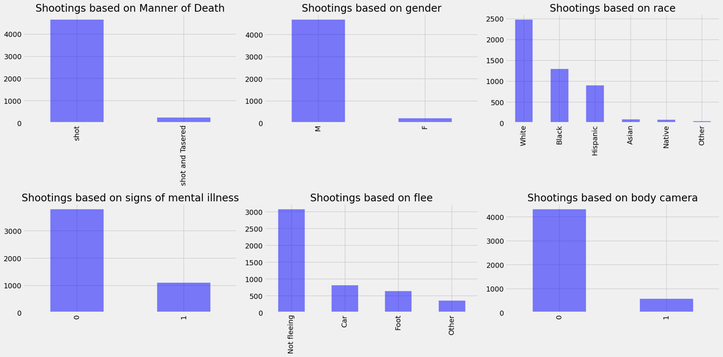

```python
plt.figure(figsize=(20,10))
plt.subplot(2,3,1)
df['Manner_of_death'].value_counts().plot(kind = 'bar', title = 'Shootings based on Manner of Death', color = 'blue', alpha = 0.5)
plt.subplot(2,3,2)
df['Gender'].value_counts().plot(kind = 'bar', title = 'Shootings based on gender', color = 'blue', alpha = 0.5)
plt.subplot(2,3,3)
df['Race'].value_counts().plot(kind = 'bar', title = 'Shootings based on race', color = 'blue', alpha = 0.5)
plt.subplot(2,3,4)
df['Signs_of_mental_illness'].value_counts().plot(kind = 'bar', title = 'Shootings based on signs of mental illness', alpha = 0.5,color = 'blue')
plt.subplot(2,3,5)
df['Flee'].value_counts().plot(kind = 'bar', title = 'Shootings based on flee', color = 'blue', alpha = 0.5)
plt.subplot(2,3,6)
df['Body_camera'].value_counts().plot(kind = 'bar', title = 'Shootings based on body camera', color = 'blue', alpha = 0.5)
plt.tight_layout()
plt.show()
```

The possible insights that can be drawn from the bar charts were:

**1. Number of deaths based on the manner of death:** There are relatively more people who died from gunshots than people who died from shot and tasered.

**2. Number of deaths based on gender:** It is clear that males are more likely to die from shootings.

**3. Number of deaths based on race:** White people who died from shootings are more compared to other racial groups.

**5. Number of deaths based on the action of fleeing:** There is a large number of people who died that did not flee.

**6. Number of deaths based on body camera:** The people who do not have a body camera tend to result in more deaths compared to people who have a body camera.

As we can see, shootings account for the majority of the incidents. Tasering is typically a challenging procedure that requires the officers to be dangerously near to potentially armed suspects. As a result, officers typically choose to use force to neutralise threats.

### **Research Question 2:** Is there a disparity in the occurrence of fatal shootings by the police, with a higher incidence observed among younger individuals compared to those of older age groups?

```python
standard_age = 25
age_group = []
for age in df['Age']:
    if age<25:
        age_group.append('Young')
    else:
        age_group.append('Old')

df['Age Group'] = age_group
```

```
Old      4044
Young     850
Name: Age Group, dtype: int64
```

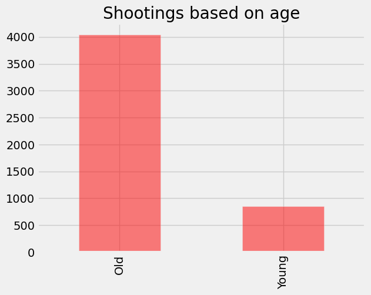

```python
print(df['Age Group'].value_counts())
df['Age Group'].value_counts().plot(kind = 'bar', title = 'Shootings based on age', color = 'red', alpha = 0.5)
plt.show()
```

According to the data, people who were classified as "Old" were involved in 4,044 fatal shootings, whereas people who were classified as "Young" were involved in 850 occurrences. This suggests a significant variation in the number of fatal gunshots, suggesting a higher incidence among the older demographic. Subsequent examination may investigate additional factors or trends underlying the observed discrepancy. People less than 25 years of age are facing less fatal shootings than the old people.

### **Research Question 3:** At what specific year and month did the United States witness the highest number of fatal shootings?

```python
# Extracting month and year from date column and creating new columns for both
df['month'] = df['Date'].dt.month
df['year'] = df['Date'].dt.year
```

```python
count_deaths = df.groupby(['year','month'])[['month']].count().rename(columns= {'month':'count'}).reset_index()
count_deaths[count_deaths['count']==count_deaths['count'].max()]
```

|  | year | month | count |
| --- | --- | --- | --- |
| 6 | 2015 | 7 | 100 |
| 59 | 2019 | 12 | 100 |

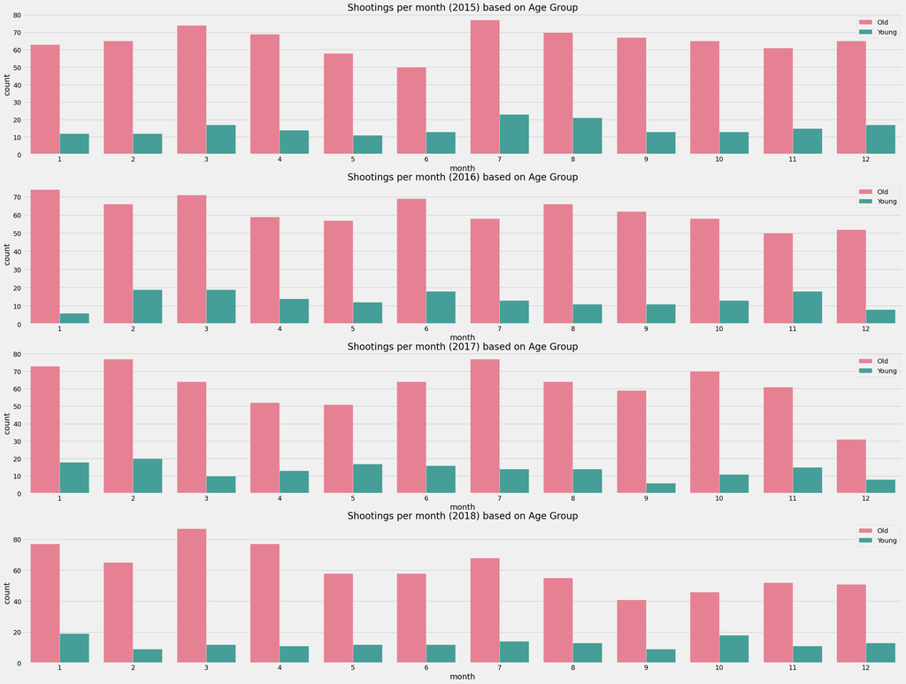

```python
plt.figure(figsize=(30, 30))
plt.subplot(5, 1, 1)
ax1 = sns.countplot(x='month',hue= 'Age Group', data=df[df['year'] == 2015], palette='husl')
ax1.legend(bbox_to_anchor=(1,1))
plt.title("Shootings per month (2015) based on Age Group", size=20)

plt.subplot(5, 1, 2)
ax2 = sns.countplot(x='month',hue= 'Age Group', data=df[df['year'] == 2016], palette='husl')
ax2.legend(bbox_to_anchor=(1,1))
plt.title("Shootings per month (2016) based on Age Group", size=20)

plt.subplot(5, 1, 3)
ax3 = sns.countplot(x='month',hue= 'Age Group', data=df[df['year'] == 2017], palette='husl')
ax3.legend(bbox_to_anchor=(1,1))
plt.title("Shootings per month (2017) based on Age Group", size=20)

plt.subplot(5, 1, 4)
ax4 = sns.countplot(x='month',hue= 'Age Group', data=df[df['year'] == 2018], palette='husl')
ax4.legend(bbox_to_anchor=(1,1))
plt.title("Shootings per month (2018) based on Age Group", size=20)
plt.show()
```

**Year 2015:**

Month 7 witnessed the highest number of fatal shootings, with a count of 100.

**Year 2019:**

Month 12 also recorded the highest number of fatal shootings, matching the count of 100.

**Yearly Breakdown:**

In 2015, fatal shootings peaked in July with a count of 100. In 2016, the highest monthly count was 90 in March. In 2017, February had the highest count at 97. In 2018, March saw the highest count of fatal shootings, totaling 99.

**Lowest Counts:** The lowest count across all years occurred in 2017, with December recording the least number of fatal shootings, totaling 39.

### **Research Question *4*:** What is the maximum percentage of shootings recorded within a particular age group?

```python
# Converting the ages number to the age groups
age_list = []
for i in df['Age']:
    if 0<i<15:
        age_list.append("0-15")
    if 15<=i<25:
        age_list.append("15-25")
    if 25<=i<35:
        age_list.append("25-35")
    if 35<=i<45:
        age_list.append("35-45")
    if 45<=i<55:
        age_list.append("45-55")
    if i>=55:
        age_list.append("more than 55")
df['Age Group'] = age_list
```

```python
df['Age Group'].value_counts(normalize=False)
```

```
25-35           1678
35-45           1122
15-25            843
45-55            735
more than 55     509
0-15               7
Name: Age Group, dtype: int64
```

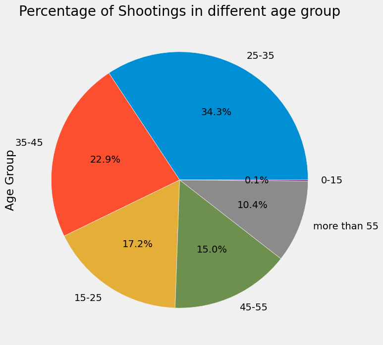

```python
df['Age Group'].value_counts(normalize=False).plot(kind='pie', figsize=(8,8),autopct='%1.1f%%')
plt.title('Percentage of Shootings in different age group', fontsize =20)
plt.show()
```

According to the data, there were more deaths in the 25–35 age range, indicating that those in their late 20s to mid-30s are more prone to encounter these kinds of situations. This might be the case because people in this age group are either more likely to be involved in social activities or to be in risky situations.

The information makes us think about how people's living situations—whether they are in cities or rural areas—and their economic circumstances affect these trends. It also begs the question of how law enforcement deals with various age groups.

### **Research Question 5:** Which five States in the United States experience the highest number of fatal shootings?

```python
df.State.value_counts(normalize=False)
```

```
California              701
Texas                   426
Florida                 324
Arizona                 222
Colorado                168
Georgia                 160
Oklahoma                151
North Carolina          148
Ohio                    146
Washington              126
Tennessee               125
Missouri                124
Louisiana               102
Illinois                 99
Pennsylvania             95
Alabama                  95
New Mexico               93
Virginia                 92
Indiana                  91
New York                 90
Wisconsin                88
Kentucky                 87
Nevada                   85
South Carolina           80
Maryland                 77
Oregon                   76
Arkansas                 73
Michigan                 71
Mississippi              61
New Jersey               60
Minnesota                60
Utah                     58
Kansas                   49
West Virginia            46
Idaho                    37
Alaska                   36
Massachusetts            33
Iowa                     31
Montana                  29
Hawaii                   29
Nebraska                 24
Maine                    21
Connecticut              20
South Dakota             14
District of Columbia     13
Wyoming                  13
New Hampshire            12
North Dakota             11
Delaware                 10
Vermont                   8
Rhode Island              4
Name: State, dtype: int64
```

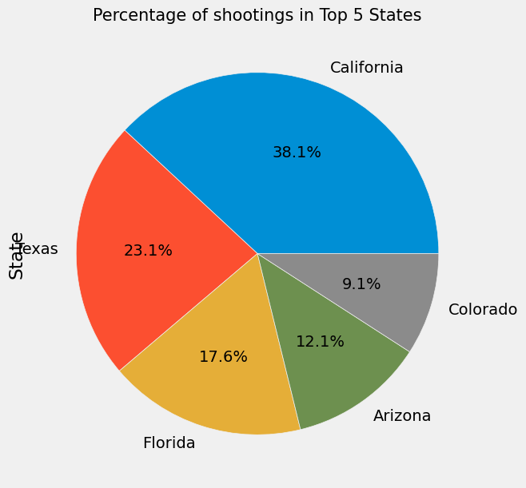

```python
df.State.value_counts(normalize=False)[:5].plot(kind='pie', figsize=(7,7),autopct='%1.1f%%')
plt.title('Percentage of shootings in Top 5 States', fontsize = 15)
plt.show()
```

The five states with the highest rate of fatal shootings are California, Texas, Florida, Arizona, and Colorado. These states' distinct socioeconomic environments, high population densities, and varied demographics are all contributing causes to this high rate of shootings. Although the larger states—Texas and California—face complicated issues related to their sizable populations, Florida's higher numbers may be explained by the state's distinct regional dynamics and Texas' distinctive cultural characteristics.

The significance of taking into account per capita rates is highlighted by lower counts in smaller states, and patterns in regional variance ought to be investigated. Interventions like community policing programmes, improved de-escalation training, mental health services, more open data, and more community involvement in policing policy are essential for creating safer communities and addressing local issues in order to reduce the number of fatal shootings.

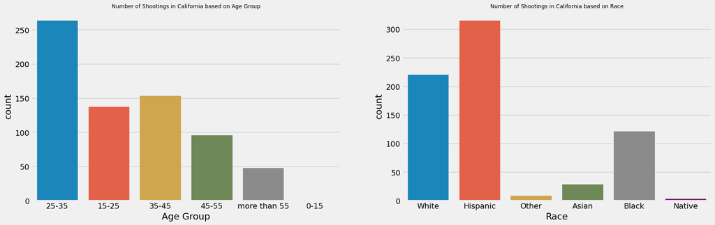

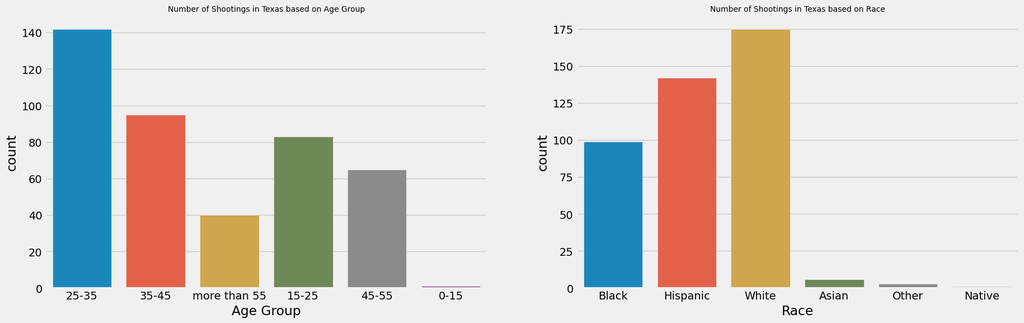

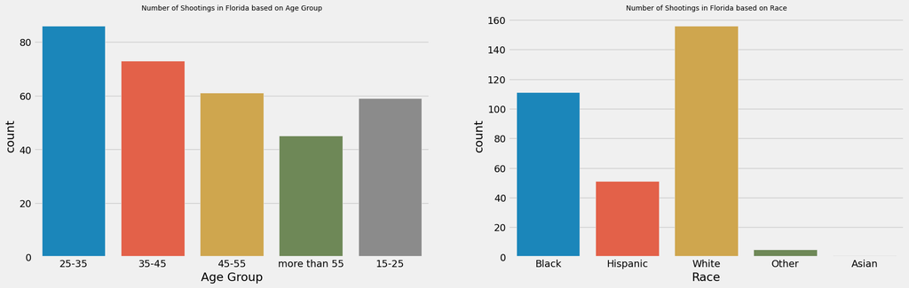

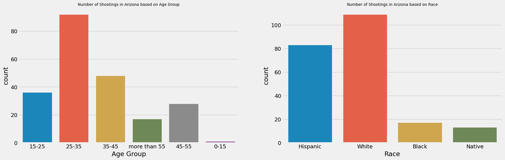

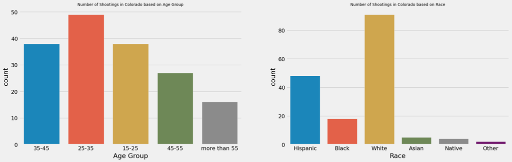

```python
for state in df.State.value_counts(normalize=False)[:5].index:
    plt.figure(figsize=(20,6))
    new_df = df[df['State'] == state]
    plt.subplot(1,2,1)
    ax2 = sns.countplot(x='Age Group', data=new_df)
    plt.title("Number of Shootings in {} based on Age Group".format(state), size=10)

    plt.subplot(1,2,2)
    ax2 = sns.countplot(x='Race', data=new_df)
    plt.title("Number of Shootings in {} based on Race".format(state), size=10)
    plt.show()
plt.show()
```

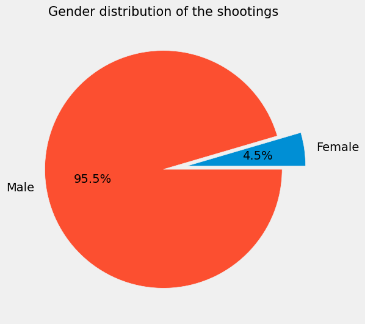

```python
df_gend=df.groupby('Gender')[['Gender']].count()
plt.figure(figsize=(6,6))
labels=['Female','Male']
plt.pie(df_gend['Gender'],autopct="%1.1f%%",explode=(0.2,0),labels=labels)
plt.title('Gender distribution of the shootings',size=15)
plt.show()
```

### **Research Question 6:** What are the racial demographics of individuals who tragically lost their lives due to fatal shootings in the United States?

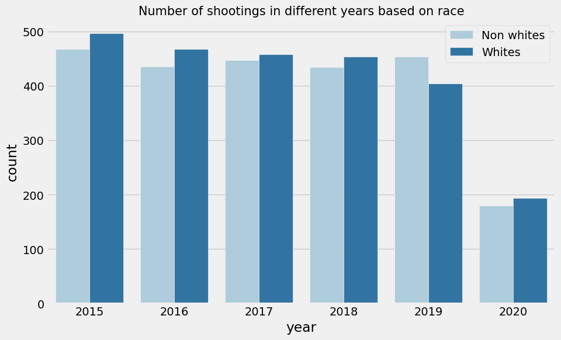

```python
plt.figure(figsize=(10, 6))
ax2 = sns.countplot(x='year',hue= 'Race Category', data=df, palette ='Paired')
legend_labels, _= ax2.get_legend_handles_labels()
ax2.legend(['Non whites', 'Whites'],bbox_to_anchor=(1,1))
plt.title("Number of shootings in different years based on race", size=15)
plt.show()
```

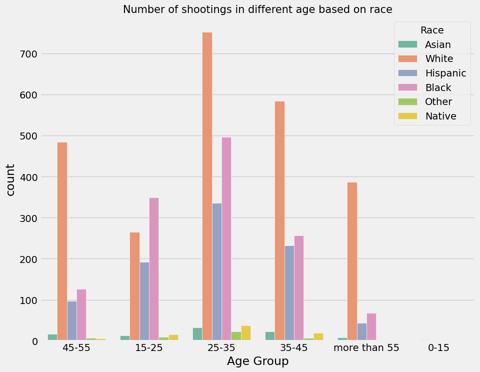

```python
plt.figure(figsize=(10, 8))
ax2 = sns.countplot(x='Age Group',hue= 'Race', data=df, palette ='Set2')
legend_labels, _= ax2.get_legend_handles_labels()
plt.title("Number of shootings in different age based on race", size=15)
plt.show()
```

The provided data outlines the count of individuals who tragically lost their lives due to fatal shootings in the United States, categorized by race (0 representing non-whites and 1 representing whites) across different years.

**2019 Anomaly:**

In 2019, there was a reversal in the trend, with 454 fatal shootings involving non-white individuals and 404 involving white individuals. This anomaly merits further investigation to understand the factors contributing to the shift in counts.

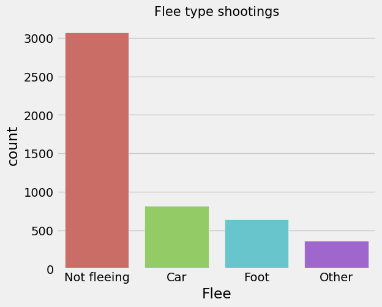

```python
plt.figure(figsize=(6, 5))
ax2 = sns.countplot(x='Flee', data=df, palette ='hls')
legend_labels, _= ax2.get_legend_handles_labels()
plt.title("Flee type shootings", size=15)
plt.show()
```

- The larger number of shooting deaths in which victims are not running away may suggest that the use of lethal force in non-fleeing circumstances needs to be closely examined and evaluated.
- Shootings involving people in cars and on foot draw attention to particular situations where law enforcement may need to receive specialised training in order to reduce the likelihood of deadly consequences.
- The "Other" category adds variation and emphasises the value of thorough reporting to capture the subtle differences between various flee kinds.

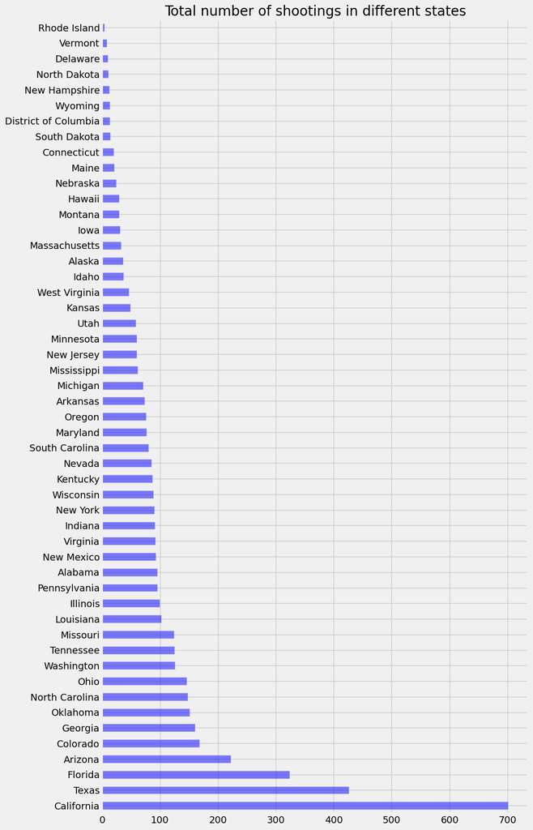

```python
df.State.value_counts(normalize=False).plot(kind='barh', figsize=(10,20), color ='blue', alpha = 0.5)
plt.title('Total number of shootings in different states', fontsize = 20)
plt.show()
```

### Research Question 7: How does the use of lethal force by law enforcement in fatal shootings vary across different ethnicities, and what factors influence police decision-making in these situations?

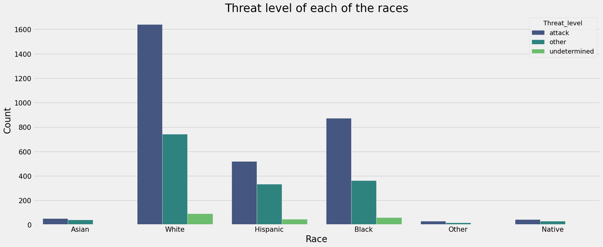

```python
plt.figure(figsize=(20,8))
sns.countplot(x='Race', data=df, hue='Threat_level', palette='viridis')

plt.xticks(size=15)
plt.xlabel('Race',size=20)
plt.yticks(size=15)
plt.ylabel('Count',size=20)
plt.title('Threat level of each of the races',size=25)
plt.show()
```

> The only choice left to them is to use a deadly shot to neutralise the offender if they begin attacking the cops.

# Part 3: Hypothesis Testing and Statistical Inference

#### **Hypothesis:** Fatal outcomes are more likely when individuals who are armed attempt to flee from law enforcement.

### > H0: There is no significant association between being armed and attempting to flee from law enforcement with the occurrence of fatal outcomes.

### > Ha: There is a significant association between being armed and attempting to flee from law enforcement with the occurrence of fatal outcomes.

```python
contingency_table = pd.crosstab(df['Armed'] == 'Armed', df['Flee'] == 'Car')

# Perform chi-squared test
chi2, p, _, _ = chi2_contingency(contingency_table)

print(f'Chi-squared value: {chi2}')
print(f'p-value: {p}')

# Check the p-value to determine statistical significance
if p < 0.05:
    print('The hypothesis is statistically significant.')
else:
    print('The hypothesis is not statistically significant.')
```

```
Chi-squared value: 0.0
p-value: 1.0
The hypothesis is not statistically significant.
```